# Experiments with tf-idf #1

James Muguira

1/9/2019

## Introduction

In this post, I’ll experiment with term frequency and inverse document frequency (tf-idf). For data, I’ll use 2 texts on design thinking. Design thinking, defined at a very high level, is the act of using tools from design to explore and devise new solutions to problems. The term is generally applied to busines and managemnt problems.

A core aspect of design thinking is striving to gain an understanding of the people that will be using the solution. This understanding comes from gaining a connection to the people you are designing for. Asking and answering questions like: why do these people do this work, what do people think about and how do they feel as they perform is work. This deep connection and the act of sharing another persons feelings are called empathy. The better the designer connects with and understands the persons feelings, the better of a solution the design can devise to help solve their problem.

As you search the internet for information, you type in keywords and the search tools bring various media back for your evaluation. A keyword search is a very rough approximation of what you are looking for. You still have to evaluate many documents and different types of media to find exactly what you are are looking for. Your mind processes this returned information using our learned ability at natural language processing (NLP). NLP for the computer is a wide range of statistical and information evaluation techniques that forms a subset of what the human mind can perform.

## Methods

In this article, I’m going to evaluate 2 documents and show how term frequency can be used to expose the information found in a document. To prepare for this article I downloaded 2 articles on design thinking, read them and hand coded the articles to capture their meaning and to locate key paragraphs and sentences that indicate the document subject matter.

Our 2 document are:

- https://dschool-old.stanford.edu/sandbox/groups/designresources/wiki/36873/attachments/74b3d/ModeGuideBOOTCAMP2010L.pdf
- https://www.researchgate.net/publication/273126653_Perspective_and_Use_of_Empathy_in_Design_Thinking/download

The 2 documents both mention empathy as a critical aspect of design thinking. The stanford document is the Stanford University guide to design thinking. It describes the Stanford Design School’s methods of applying design thinking. Their method contains 5 aspects of design thinking. The document describes design thinking from a process perspective.

The second document, which I’ll refer to as the Gasparini document, focuses on empathy. It explores application of the design thinking method in a workshop setting. It explores the role of people involved in a design thinking exerise. It highlights the need to incorproate more of what the participants are thinking about as they work through the stages of the design thinking process. The paper specifically describes the need to stop and discuss cognitive processes.

## Data Processing

To get started I’ll put each doc in its own variable and later join these variables into a tibble.

```r
#
# pull the documents in and translate from pdf to text
pdf_stan <- pdf_text("./ModeGuideBOOTCAMP2010.pdf")
pdf_gasparini <- pdf_text("./gasparini-final-3.pdf")
```

Let’s use the tidy verse set of tools to manipulate our document. A tidy document is a data frame with at least 2 columns: a list of words and a count of the number of times that word is found in the document.

```r
# turn our data in to tbls
df_stan <- data_frame(line=1:11,text=pdf_stan)
df_gasparini <- data_frame(line=1:7, text=pdf_gasparini)
#
# data into tidy format
df_stan_tidy <- df_stan %>%
  unnest_tokens(word, text)
#
# get to tidy format - note I remove strange unicode words with the mutate
df_gasparini_tidy <- df_gasparini %>%
  unnest_tokens(word, text) %>%
  mutate(word = str_extract(word, "[a-z']+"))

head(df_stan_tidy)
```

```
## # A tibble: 6 x 2
##    line word
##   <int> <chr>
## 1     1 an
## 2     1 introduction
## 3     1 to
## 4     1 design
## 5     1 thinking
## 6     1 process
```

```r
head(df_gasparini_tidy)
```

```
## # A tibble: 6 x 2
##    line word
##   <int> <chr>
## 1     1 see
## 2     1 discussions
## 3     1 stats
## 4     1 and
## 5     1 author
## 6     1 profiles
```

To explore term frequency, let’s join these data frames. While I’m at it, I’ll remove stop words

```r
data("stop_words")
#
# remove stop words and get the columns right { word, n, book }
df_stan_tidy <- df_stan_tidy %>% anti_join(stop_words)
# generate a raw count of the number of times a word is found in the document
df_stan_tidy <- df_stan_tidy %>% count(word,sort=TRUE)
# use mutate to add a "book" column to the tibble
df_stan_tidy <- mutate(df_stan_tidy, book=rep("stanford", nrow(df_stan_tidy)))

df_gasparini_tidy <- df_gasparini_tidy %>% anti_join(stop_words)
# generate a raw count of the number of times a word is found in the document
df_gasparini_tidy <- df_gasparini_tidy %>% count(word, sort=TRUE)
# again, use mutate to add a "book" column to the tibble
df_gasparini_tidy <- mutate(df_gasparini_tidy, book=rep("gasparini", nrow(df_gasparini_tidy)))
```

With the cleaning and arranging out of the way we can visually explore the respective data sets.

First, we look at the stanford document by creating a diagram showing the most used words in the document. We’ll do the same diagram for the Gaspranini document.

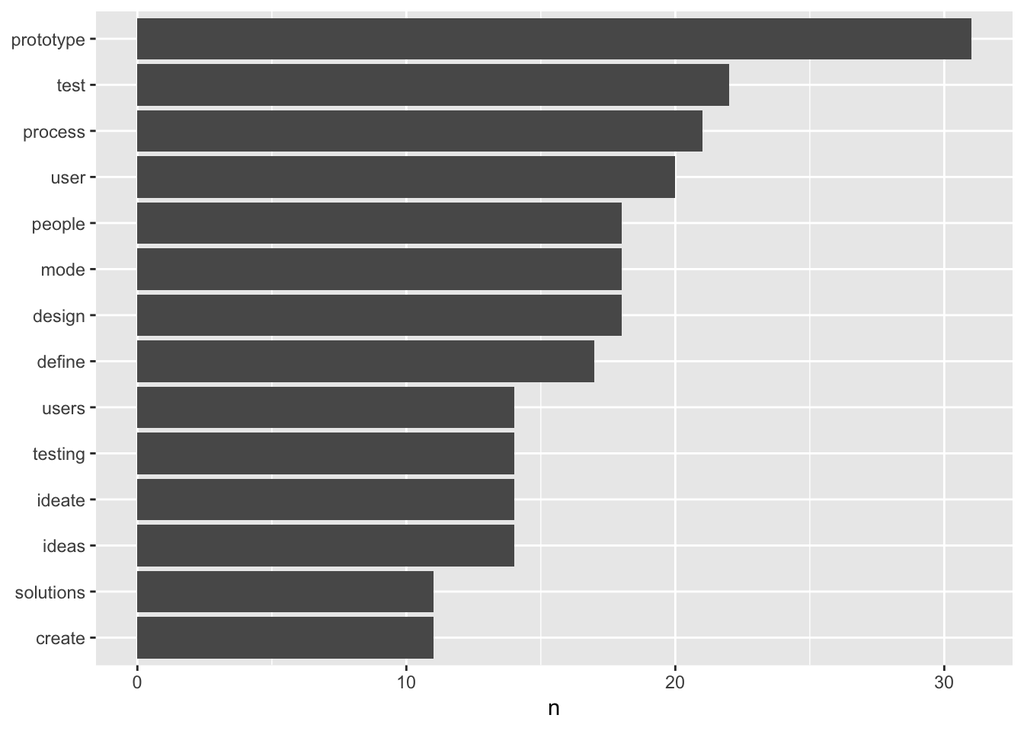

```r
df_stan_tidy %>%
  filter(n > 10) %>%
  mutate(word = reorder(word, n)) %>%
  ggplot(aes(word, n)) +
  geom_col() +
  xlab(NULL) +
  coord_flip()
```

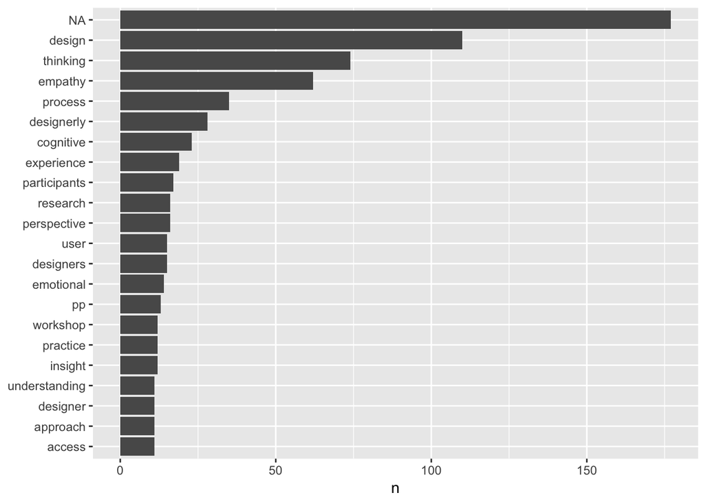

```r
df_gasparini_tidy %>%
  filter(n > 10) %>%
  mutate(word = reorder(word, n)) %>%
  ggplot(aes(word, n)) +
  geom_col() +
  xlab(NULL) +
  coord_flip()
```

As you can see, just counting the words reveals some interesting information about the content of the documents. With the Gasparanini document you can start to gain a sense of what the document is talking about. Words like:

- design
- thinking
- empathy
- process
- cognitive
- …

All are listed. The Stanford document is a little more vague. Even though term frequency is a simple tool, it has exposed some of the structure of the document. When using it to explore structure and aid in finding documents that would help with a search it counts and weights terms that are frequently used within a single document.

If we combine term frequency with inverse document frequency, we can expose structure across a set of documents. This next section will apply term frequency, inverse document frequency (tf-idf).

```r
#
# create a single bag of words for term freq
bag_of_words <- rbind(df_stan_tidy, df_gasparini_tidy)
bag_of_words <- bag_of_words %>%
  bind_tf_idf(word, book, n)
#
# and sort
bag_of_words %>% arrange(desc(tf_idf))
```

```
## # A tibble: 1,331 x 6
##    word             n book           tf   idf  tf_idf
##    <chr>        <int> <chr>       <dbl> <dbl>   <dbl>
##  1 test            22 stanford  0.0180  0.693 0.0125
##  2 mode            18 stanford  0.0148  0.693 0.0102
##  3 ideate          14 stanford  0.0115  0.693 0.00795
##  4 testing         14 stanford  0.0115  0.693 0.00795
##  5 cognitive       23 gasparini 0.0112  0.693 0.00780
##  6 participants    17 gasparini 0.00831 0.693 0.00576
##  7 ideation        10 stanford  0.00820 0.693 0.00568
##  8 perspective     16 gasparini 0.00782 0.693 0.00542
##  9 conversation     9 stanford  0.00738 0.693 0.00511
## 10 empathize        9 stanford  0.00738 0.693 0.00511
## # … with 1,321 more rows
```

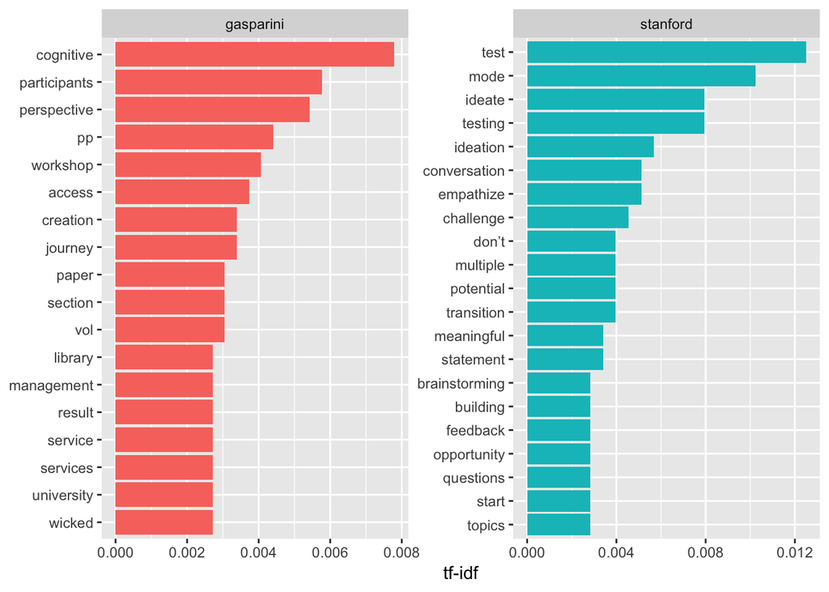

```r
#
# finally, create a visual...
bag_of_words %>%
  arrange(desc(tf_idf)) %>%
  mutate(word = factor(word, levels = rev(unique(word)))) %>%
  group_by(book) %>%
  top_n(15) %>%
  ungroup %>%
  ggplot(aes(word, tf_idf, fill = book)) +
  geom_col(show.legend = FALSE) +
  labs(x = NULL, y = "tf-idf") +
  facet_wrap(~book, ncol = 2, scales = "free") +
  coord_flip()
```

Visual inspection of our analysis some what aligns with the hand annotation of the gasparini paper. The Gasparini paper is a case study of a conference where design thinking was applied. This is reflected in the term frequency graphic on the left. The TF-IDF analysis reveals terms such as cognitive, participants, workshop, creation and journey.

# Conclusion

In this case, analyzing the documents with term frequency techniques revealed some interesting items. The techniques helped us to identify terms like: workshop and participant in the Gasparnini paper. In the Stanford paper, the techniques exposed process related terms such as testing, brainstorming and conversation. However, the single words exposed from the term frequency techniques were not that helpful as aids to discover document content. The next paper in this series will strive to correct this.